# Risk Factor Analysis

## Outcome Variable

**Outcome Variable:** wast_rec90d

## Predictor Variables

**Intervention Variable:** parity

**Adjustment Set:**

- arm
- W_mage
- meducyrs
- feducyrs
- hhwealth_quart
- W_mhtcm
- vagbrth
- W_nrooms
- impsan
- delta_W_mage
- delta_meducyrs
- delta_feducyrs
- delta_hhwealth_quart
- delta_W_mhtcm
- delta_vagbrth
- delta_W_nrooms
- delta_impsan

## Stratifying Variables

The analysis was stratified on these variable(s):

- agecat
- studyid
- country

## Data Summary

| agecat | studyid | country | parity | wast_rec90d | n_cell | n |
| --- | --- | --- | --- | --- | --- | --- |
| 0-24 months | ki1000304b-SAS-CompFeed | INDIA | 1 | 0 | 136 | 814 |
| 0-24 months | ki1000304b-SAS-CompFeed | INDIA | 1 | 1 | 91 | 814 |
| 0-24 months | ki1000304b-SAS-CompFeed | INDIA | 2 | 0 | 110 | 814 |
| 0-24 months | ki1000304b-SAS-CompFeed | INDIA | 2 | 1 | 62 | 814 |
| 0-24 months | ki1000304b-SAS-CompFeed | INDIA | 3+ | 0 | 258 | 814 |
| 0-24 months | ki1000304b-SAS-CompFeed | INDIA | 3+ | 1 | 157 | 814 |
| 0-24 months | ki1000304b-SAS-FoodSuppl | INDIA | 1 | 0 | 30 | 223 |
| 0-24 months | ki1000304b-SAS-FoodSuppl | INDIA | 1 | 1 | 2 | 223 |
| 0-24 months | ki1000304b-SAS-FoodSuppl | INDIA | 2 | 0 | 47 | 223 |
| 0-24 months | ki1000304b-SAS-FoodSuppl | INDIA | 2 | 1 | 3 | 223 |
| 0-24 months | ki1000304b-SAS-FoodSuppl | INDIA | 3+ | 0 | 133 | 223 |
| 0-24 months | ki1000304b-SAS-FoodSuppl | INDIA | 3+ | 1 | 8 | 223 |
| 0-24 months | ki1017093b-PROVIDE | BANGLADESH | 1 | 0 | 52 | 307 |
| 0-24 months | ki1017093b-PROVIDE | BANGLADESH | 1 | 1 | 76 | 307 |
| 0-24 months | ki1017093b-PROVIDE | BANGLADESH | 2 | 0 | 40 | 307 |
| 0-24 months | ki1017093b-PROVIDE | BANGLADESH | 2 | 1 | 63 | 307 |
| 0-24 months | ki1017093b-PROVIDE | BANGLADESH | 3+ | 0 | 36 | 307 |
| 0-24 months | ki1017093b-PROVIDE | BANGLADESH | 3+ | 1 | 40 | 307 |
| 0-24 months | ki1066203-TanzaniaChild2 | TANZANIA, UNITED REPUBLIC OF | 1 | 0 | 90 | 702 |
| 0-24 months | ki1066203-TanzaniaChild2 | TANZANIA, UNITED REPUBLIC OF | 1 | 1 | 158 | 702 |
| 0-24 months | ki1066203-TanzaniaChild2 | TANZANIA, UNITED REPUBLIC OF | 2 | 0 | 83 | 702 |
| 0-24 months | ki1066203-TanzaniaChild2 | TANZANIA, UNITED REPUBLIC OF | 2 | 1 | 155 | 702 |
| 0-24 months | ki1066203-TanzaniaChild2 | TANZANIA, UNITED REPUBLIC OF | 3+ | 0 | 90 | 702 |
| 0-24 months | ki1066203-TanzaniaChild2 | TANZANIA, UNITED REPUBLIC OF | 3+ | 1 | 126 | 702 |
| 0-24 months | ki1101329-Keneba | GAMBIA | 1 | 0 | 44 | 1164 |
| 0-24 months | ki1101329-Keneba | GAMBIA | 1 | 1 | 79 | 1164 |
| 0-24 months | ki1101329-Keneba | GAMBIA | 2 | 0 | 43 | 1164 |
| 0-24 months | ki1101329-Keneba | GAMBIA | 2 | 1 | 66 | 1164 |
| 0-24 months | ki1101329-Keneba | GAMBIA | 3+ | 0 | 429 | 1164 |
| 0-24 months | ki1101329-Keneba | GAMBIA | 3+ | 1 | 503 | 1164 |

[output cut: 168 more lines]

The following strata were considered:

- agecat: 0-24 months, studyid: ki1000304b-SAS-CompFeed, country: INDIA
- agecat: 0-24 months, studyid: ki1000304b-SAS-FoodSuppl, country: INDIA
- agecat: 0-24 months, studyid: ki1017093b-PROVIDE, country: BANGLADESH
- agecat: 0-24 months, studyid: ki1066203-TanzaniaChild2, country: TANZANIA, UNITED REPUBLIC OF
- agecat: 0-24 months, studyid: ki1101329-Keneba, country: GAMBIA
- agecat: 0-24 months, studyid: ki1113344-GMS-Nepal, country: NEPAL
- agecat: 0-24 months, studyid: ki1126311-ZVITAMBO, country: ZIMBABWE
- agecat: 0-24 months, studyid: ki1135781-COHORTS, country: GUATEMALA
- agecat: 0-24 months, studyid: ki1135781-COHORTS, country: INDIA
- agecat: 0-24 months, studyid: ki1135781-COHORTS, country: PHILIPPINES
- agecat: 0-24 months, studyid: kiGH5241-JiVitA-3, country: BANGLADESH
- agecat: 0-6 months, studyid: ki1000304b-SAS-CompFeed, country: INDIA
- agecat: 0-6 months, studyid: ki1000304b-SAS-FoodSuppl, country: INDIA
- agecat: 0-6 months, studyid: ki1017093b-PROVIDE, country: BANGLADESH
- agecat: 0-6 months, studyid: ki1066203-TanzaniaChild2, country: TANZANIA, UNITED REPUBLIC OF
- agecat: 0-6 months, studyid: ki1101329-Keneba, country: GAMBIA
- agecat: 0-6 months, studyid: ki1113344-GMS-Nepal, country: NEPAL
- agecat: 0-6 months, studyid: ki1126311-ZVITAMBO, country: ZIMBABWE
- agecat: 0-6 months, studyid: ki1135781-COHORTS, country: GUATEMALA
- agecat: 0-6 months, studyid: ki1135781-COHORTS, country: INDIA
- agecat: 0-6 months, studyid: ki1135781-COHORTS, country: PHILIPPINES
- agecat: 0-6 months, studyid: kiGH5241-JiVitA-3, country: BANGLADESH
- agecat: 6-24 months, studyid: ki1000304b-SAS-CompFeed, country: INDIA
- agecat: 6-24 months, studyid: ki1000304b-SAS-FoodSuppl, country: INDIA
- agecat: 6-24 months, studyid: ki1017093b-PROVIDE, country: BANGLADESH
- agecat: 6-24 months, studyid: ki1066203-TanzaniaChild2, country: TANZANIA, UNITED REPUBLIC OF
- agecat: 6-24 months, studyid: ki1101329-Keneba, country: GAMBIA
- agecat: 6-24 months, studyid: ki1113344-GMS-Nepal, country: NEPAL
- agecat: 6-24 months, studyid: ki1126311-ZVITAMBO, country: ZIMBABWE
- agecat: 6-24 months, studyid: ki1135781-COHORTS, country: GUATEMALA
- agecat: 6-24 months, studyid: ki1135781-COHORTS, country: INDIA
- agecat: 6-24 months, studyid: ki1135781-COHORTS, country: PHILIPPINES
- agecat: 6-24 months, studyid: kiGH5241-JiVitA-3, country: BANGLADESH

### Dropped Strata

Some strata were dropped due to rare outcomes:

- agecat: 0-24 months, studyid: ki1000304b-SAS-FoodSuppl, country: INDIA
- agecat: 0-6 months, studyid: ki1000304b-SAS-FoodSuppl, country: INDIA
- agecat: 6-24 months, studyid: ki1000304b-SAS-FoodSuppl, country: INDIA
- agecat: 6-24 months, studyid: ki1135781-COHORTS, country: GUATEMALA
- agecat: 6-24 months, studyid: ki1135781-COHORTS, country: INDIA
- agecat: 6-24 months, studyid: kiGH5241-JiVitA-3, country: BANGLADESH

## Methods Detail

We’re interested in the causal parameters $E[Y_a]$ for all values of $a \in \mathcal{A}$. These parameters represent the mean outcome if, possibly contrary to fact, we intervened to set all units to have $A=a$. Under the randomization and positivity assumptions, these are identified by the statistical parameters $\psi_a=E_W[E_{Y|A,W}(Y|A=a,W)]$. In addition, we’re interested in the mean of $Y$, $E[Y]$ under no intervention (the observed mean). We will estimate these parameters by using SuperLearner to fit the relevant likelihood factors – $E_{Y|A,W}(Y|A=a,W)$ and $p(A=a|W)$, and then updating our likelihood fit using a joint TMLE.

For unadjusted analyses ($W=\{\}$), initial likelihoods were estimated using Lrnr_glm to estimate the simple $E(Y|A)$ and Lrnr_mean to estimate $p(A)$. For adjusted analyses, a small library containing Lrnr_glmnet, Lrnr_xgboost, and Lrnr_mean was used.

Having estimated these parameters, we will then use the delta method to estimate relative risks and attributable risks relative to a prespecified baseline level of $A$.

# Results Detail

## Results Plots

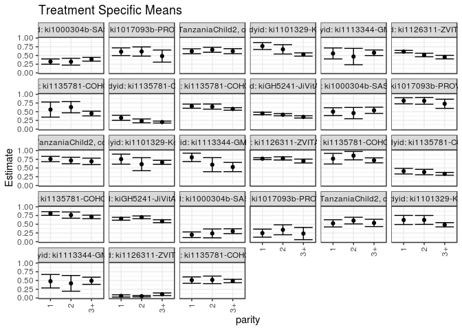

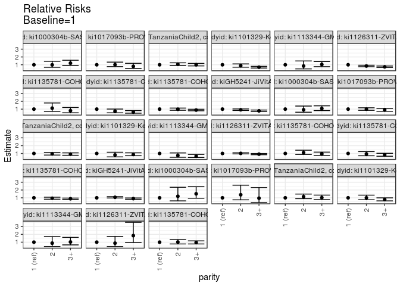

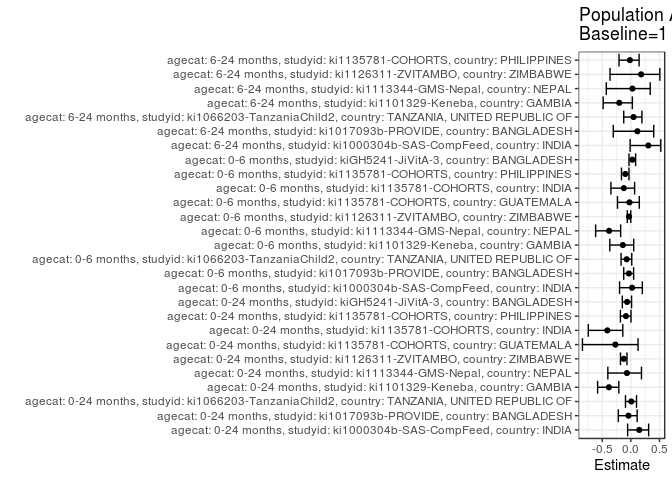

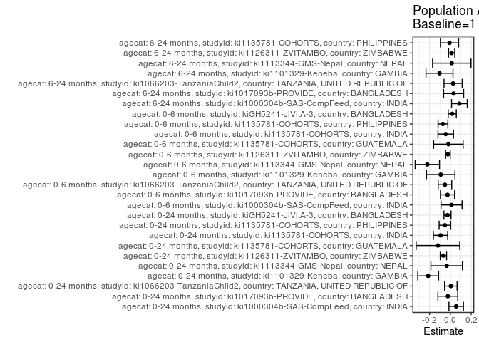

## Results Table

### Parameter: TSM

| agecat | studyid | country | intervention_level | baseline_level | estimate | ci_lower | ci_upper |
| --- | --- | --- | --- | --- | --- | --- | --- |
| 0-24 months | ki1000304b-SAS-CompFeed | INDIA | 1 | NA | 0.3248940 | 0.2492873 | 0.4005006 |
| 0-24 months | ki1000304b-SAS-CompFeed | INDIA | 2 | NA | 0.3215164 | 0.2238114 | 0.4192215 |
| 0-24 months | ki1000304b-SAS-CompFeed | INDIA | 3+ | NA | 0.3912661 | 0.3364905 | 0.4460416 |
| 0-24 months | ki1017093b-PROVIDE | BANGLADESH | 1 | NA | 0.6073629 | 0.4968908 | 0.7178351 |
| 0-24 months | ki1017093b-PROVIDE | BANGLADESH | 2 | NA | 0.6133219 | 0.4817448 | 0.7448990 |
| 0-24 months | ki1017093b-PROVIDE | BANGLADESH | 3+ | NA | 0.4825560 | 0.3090661 | 0.6560458 |
| 0-24 months | ki1066203-TanzaniaChild2 | TANZANIA, UNITED REPUBLIC OF | 1 | NA | 0.6207315 | 0.5500570 | 0.6914060 |
| 0-24 months | ki1066203-TanzaniaChild2 | TANZANIA, UNITED REPUBLIC OF | 2 | NA | 0.6630305 | 0.5908890 | 0.7351720 |
| 0-24 months | ki1066203-TanzaniaChild2 | TANZANIA, UNITED REPUBLIC OF | 3+ | NA | 0.6228566 | 0.5506728 | 0.6950404 |
| 0-24 months | ki1101329-Keneba | GAMBIA | 1 | NA | 0.7700403 | 0.6701547 | 0.8699260 |
| 0-24 months | ki1101329-Keneba | GAMBIA | 2 | NA | 0.6755145 | 0.5418604 | 0.8091686 |
| 0-24 months | ki1101329-Keneba | GAMBIA | 3+ | NA | 0.5281434 | 0.4814307 | 0.5748561 |
| 0-24 months | ki1113344-GMS-Nepal | NEPAL | 1 | NA | 0.5581075 | 0.4010080 | 0.7152071 |
| 0-24 months | ki1113344-GMS-Nepal | NEPAL | 2 | NA | 0.4685721 | 0.2340202 | 0.7031240 |
| 0-24 months | ki1113344-GMS-Nepal | NEPAL | 3+ | NA | 0.5776522 | 0.4981329 | 0.6571715 |
| 0-24 months | ki1126311-ZVITAMBO | ZIMBABWE | 1 | NA | 0.6109507 | 0.5765752 | 0.6453262 |
| 0-24 months | ki1126311-ZVITAMBO | ZIMBABWE | 2 | NA | 0.5136575 | 0.4629952 | 0.5643198 |
| 0-24 months | ki1126311-ZVITAMBO | ZIMBABWE | 3+ | NA | 0.4529916 | 0.4020861 | 0.5038972 |
| 0-24 months | ki1135781-COHORTS | GUATEMALA | 1 | NA | 0.5616444 | 0.3449726 | 0.7783161 |
| 0-24 months | ki1135781-COHORTS | GUATEMALA | 2 | NA | 0.6312247 | 0.4691191 | 0.7933303 |
| 0-24 months | ki1135781-COHORTS | GUATEMALA | 3+ | NA | 0.4487451 | 0.3809384 | 0.5165517 |
| 0-24 months | ki1135781-COHORTS | INDIA | 1 | NA | 0.3253908 | 0.2522331 | 0.3985484 |
| 0-24 months | ki1135781-COHORTS | INDIA | 2 | NA | 0.2370802 | 0.1815643 | 0.2925961 |
| 0-24 months | ki1135781-COHORTS | INDIA | 3+ | NA | 0.2033263 | 0.1758611 | 0.2307915 |
| 0-24 months | ki1135781-COHORTS | PHILIPPINES | 1 | NA | 0.6590931 | 0.5997120 | 0.7184742 |
| 0-24 months | ki1135781-COHORTS | PHILIPPINES | 2 | NA | 0.6469611 | 0.5735074 | 0.7204149 |
| 0-24 months | ki1135781-COHORTS | PHILIPPINES | 3+ | NA | 0.5794667 | 0.5432605 | 0.6156730 |
| 0-24 months | kiGH5241-JiVitA-3 | BANGLADESH | 1 | NA | 0.4500762 | 0.4142050 | 0.4859474 |
| 0-24 months | kiGH5241-JiVitA-3 | BANGLADESH | 2 | NA | 0.4137232 | 0.3831199 | 0.4443266 |
| 0-24 months | kiGH5241-JiVitA-3 | BANGLADESH | 3+ | NA | 0.3513518 | 0.3192669 | 0.3834367 |

[output cut: 51 more lines]

### Parameter: E(Y)

| agecat | studyid | country | intervention_level | baseline_level | estimate | ci_lower | ci_upper |
| --- | --- | --- | --- | --- | --- | --- | --- |
| 0-24 months | ki1000304b-SAS-CompFeed | INDIA | NA | NA | 0.3808354 | 0.3457640 | 0.4159068 |
| 0-24 months | ki1017093b-PROVIDE | BANGLADESH | NA | NA | 0.5830619 | 0.5262762 | 0.6398476 |
| 0-24 months | ki1066203-TanzaniaChild2 | TANZANIA, UNITED REPUBLIC OF | NA | NA | 0.6253561 | 0.5873792 | 0.6633330 |
| 0-24 months | ki1101329-Keneba | GAMBIA | NA | NA | 0.5567010 | 0.5253304 | 0.5880717 |
| 0-24 months | ki1113344-GMS-Nepal | NEPAL | NA | NA | 0.5222816 | 0.4773852 | 0.5671781 |
| 0-24 months | ki1126311-ZVITAMBO | ZIMBABWE | NA | NA | 0.5440559 | 0.5275873 | 0.5605246 |
| 0-24 months | ki1135781-COHORTS | GUATEMALA | NA | NA | 0.4421053 | 0.3904403 | 0.4937702 |
| 0-24 months | ki1135781-COHORTS | INDIA | NA | NA | 0.2306792 | 0.2105836 | 0.2507747 |
| 0-24 months | ki1135781-COHORTS | PHILIPPINES | NA | NA | 0.6068680 | 0.5823645 | 0.6313715 |
| 0-24 months | kiGH5241-JiVitA-3 | BANGLADESH | NA | NA | 0.4224719 | 0.4113451 | 0.4335987 |
| 0-6 months | ki1000304b-SAS-CompFeed | INDIA | NA | NA | 0.5131965 | 0.4596632 | 0.5667297 |
| 0-6 months | ki1017093b-PROVIDE | BANGLADESH | NA | NA | 0.7880435 | 0.7295878 | 0.8464992 |
| 0-6 months | ki1066203-TanzaniaChild2 | TANZANIA, UNITED REPUBLIC OF | NA | NA | 0.7053571 | 0.6558827 | 0.7548316 |
| 0-6 months | ki1101329-Keneba | GAMBIA | NA | NA | 0.6613924 | 0.6093076 | 0.7134773 |
| 0-6 months | ki1113344-GMS-Nepal | NEPAL | NA | NA | 0.5833333 | 0.5108676 | 0.6557991 |
| 0-6 months | ki1126311-ZVITAMBO | ZIMBABWE | NA | NA | 0.7433453 | 0.7262923 | 0.7603982 |
| 0-6 months | ki1135781-COHORTS | GUATEMALA | NA | NA | 0.7476636 | 0.6894668 | 0.8058603 |
| 0-6 months | ki1135781-COHORTS | INDIA | NA | NA | 0.3641405 | 0.3354558 | 0.3928252 |
| 0-6 months | ki1135781-COHORTS | PHILIPPINES | NA | NA | 0.7367021 | 0.7051294 | 0.7682749 |
| 0-6 months | kiGH5241-JiVitA-3 | BANGLADESH | NA | NA | 0.6752588 | 0.6619177 | 0.6885999 |
| 6-24 months | ki1000304b-SAS-CompFeed | INDIA | NA | NA | 0.2854123 | 0.2436284 | 0.3271961 |
| 6-24 months | ki1017093b-PROVIDE | BANGLADESH | NA | NA | 0.2764228 | 0.1950773 | 0.3577682 |
| 6-24 months | ki1066203-TanzaniaChild2 | TANZANIA, UNITED REPUBLIC OF | NA | NA | 0.5519126 | 0.4992021 | 0.6046230 |
| 6-24 months | ki1101329-Keneba | GAMBIA | NA | NA | 0.5176887 | 0.4814695 | 0.5539079 |
| 6-24 months | ki1113344-GMS-Nepal | NEPAL | NA | NA | 0.4934383 | 0.4388573 | 0.5480193 |
| 6-24 months | ki1126311-ZVITAMBO | ZIMBABWE | NA | NA | 0.0699433 | 0.0547084 | 0.0851781 |
| 6-24 months | ki1135781-COHORTS | PHILIPPINES | NA | NA | 0.5026681 | 0.4688378 | 0.5364984 |

### Parameter: RR

| agecat | studyid | country | intervention_level | baseline_level | estimate | ci_lower | ci_upper |
| --- | --- | --- | --- | --- | --- | --- | --- |
| 0-24 months | ki1000304b-SAS-CompFeed | INDIA | 1 | 1 | 1.0000000 | 1.0000000 | 1.0000000 |
| 0-24 months | ki1000304b-SAS-CompFeed | INDIA | 2 | 1 | 0.9896041 | 0.6750089 | 1.4508198 |
| 0-24 months | ki1000304b-SAS-CompFeed | INDIA | 3+ | 1 | 1.2042884 | 0.9180246 | 1.5798167 |
| 0-24 months | ki1017093b-PROVIDE | BANGLADESH | 1 | 1 | 1.0000000 | 1.0000000 | 1.0000000 |
| 0-24 months | ki1017093b-PROVIDE | BANGLADESH | 2 | 1 | 1.0098111 | 0.7618345 | 1.3385041 |
| 0-24 months | ki1017093b-PROVIDE | BANGLADESH | 3+ | 1 | 0.7945101 | 0.5305609 | 1.1897715 |
| 0-24 months | ki1066203-TanzaniaChild2 | TANZANIA, UNITED REPUBLIC OF | 1 | 1 | 1.0000000 | 1.0000000 | 1.0000000 |
| 0-24 months | ki1066203-TanzaniaChild2 | TANZANIA, UNITED REPUBLIC OF | 2 | 1 | 1.0681438 | 0.9126027 | 1.2501950 |
| 0-24 months | ki1066203-TanzaniaChild2 | TANZANIA, UNITED REPUBLIC OF | 3+ | 1 | 1.0034235 | 0.8529064 | 1.1805032 |
| 0-24 months | ki1101329-Keneba | GAMBIA | 1 | 1 | 1.0000000 | 1.0000000 | 1.0000000 |
| 0-24 months | ki1101329-Keneba | GAMBIA | 2 | 1 | 0.8772456 | 0.6924635 | 1.1113363 |
| 0-24 months | ki1101329-Keneba | GAMBIA | 3+ | 1 | 0.6858646 | 0.5862741 | 0.8023725 |
| 0-24 months | ki1113344-GMS-Nepal | NEPAL | 1 | 1 | 1.0000000 | 1.0000000 | 1.0000000 |
| 0-24 months | ki1113344-GMS-Nepal | NEPAL | 2 | 1 | 0.8395731 | 0.4729573 | 1.4903734 |
| 0-24 months | ki1113344-GMS-Nepal | NEPAL | 3+ | 1 | 1.0350195 | 0.7565638 | 1.4159617 |
| 0-24 months | ki1126311-ZVITAMBO | ZIMBABWE | 1 | 1 | 1.0000000 | 1.0000000 | 1.0000000 |
| 0-24 months | ki1126311-ZVITAMBO | ZIMBABWE | 2 | 1 | 0.8407511 | 0.7506665 | 0.9416465 |
| 0-24 months | ki1126311-ZVITAMBO | ZIMBABWE | 3+ | 1 | 0.7414537 | 0.6541703 | 0.8403829 |
| 0-24 months | ki1135781-COHORTS | GUATEMALA | 1 | 1 | 1.0000000 | 1.0000000 | 1.0000000 |
| 0-24 months | ki1135781-COHORTS | GUATEMALA | 2 | 1 | 1.1238869 | 0.7071873 | 1.7861205 |
| 0-24 months | ki1135781-COHORTS | GUATEMALA | 3+ | 1 | 0.7989844 | 0.5276868 | 1.2097631 |
| 0-24 months | ki1135781-COHORTS | INDIA | 1 | 1 | 1.0000000 | 1.0000000 | 1.0000000 |
| 0-24 months | ki1135781-COHORTS | INDIA | 2 | 1 | 0.7286014 | 0.5266347 | 1.0080231 |
| 0-24 months | ki1135781-COHORTS | INDIA | 3+ | 1 | 0.6248681 | 0.4807343 | 0.8122162 |
| 0-24 months | ki1135781-COHORTS | PHILIPPINES | 1 | 1 | 1.0000000 | 1.0000000 | 1.0000000 |
| 0-24 months | ki1135781-COHORTS | PHILIPPINES | 2 | 1 | 0.9815930 | 0.8492875 | 1.1345095 |
| 0-24 months | ki1135781-COHORTS | PHILIPPINES | 3+ | 1 | 0.8791880 | 0.7879163 | 0.9810325 |
| 0-24 months | kiGH5241-JiVitA-3 | BANGLADESH | 1 | 1 | 1.0000000 | 1.0000000 | 1.0000000 |
| 0-24 months | kiGH5241-JiVitA-3 | BANGLADESH | 2 | 1 | 0.9192293 | 0.8245397 | 1.0247930 |
| 0-24 months | kiGH5241-JiVitA-3 | BANGLADESH | 3+ | 1 | 0.7806497 | 0.6915555 | 0.8812220 |

[output cut: 51 more lines]

### Parameter: PAR

| agecat | studyid | country | intervention_level | baseline_level | estimate | ci_lower | ci_upper |
| --- | --- | --- | --- | --- | --- | --- | --- |
| 0-24 months | ki1000304b-SAS-CompFeed | INDIA | 1 | NA | 0.0559414 | -0.0136373 | 0.1255201 |
| 0-24 months | ki1017093b-PROVIDE | BANGLADESH | 1 | NA | -0.0243010 | -0.1196087 | 0.0710066 |
| 0-24 months | ki1066203-TanzaniaChild2 | TANZANIA, UNITED REPUBLIC OF | 1 | NA | 0.0046246 | -0.0555813 | 0.0648305 |
| 0-24 months | ki1101329-Keneba | GAMBIA | 1 | NA | -0.2133393 | -0.3135548 | -0.1131238 |
| 0-24 months | ki1113344-GMS-Nepal | NEPAL | 1 | NA | -0.0358259 | -0.1873962 | 0.1157444 |
| 0-24 months | ki1126311-ZVITAMBO | ZIMBABWE | 1 | NA | -0.0668948 | -0.0975153 | -0.0362742 |
| 0-24 months | ki1135781-COHORTS | GUATEMALA | 1 | NA | -0.1195391 | -0.3291554 | 0.0900772 |
| 0-24 months | ki1135781-COHORTS | INDIA | 1 | NA | -0.0947116 | -0.1637466 | -0.0256766 |
| 0-24 months | ki1135781-COHORTS | PHILIPPINES | 1 | NA | -0.0522251 | -0.1082332 | 0.0037830 |
| 0-24 months | kiGH5241-JiVitA-3 | BANGLADESH | 1 | NA | -0.0276043 | -0.0616791 | 0.0064705 |
| 0-6 months | ki1000304b-SAS-CompFeed | INDIA | 1 | NA | 0.0111576 | -0.0902695 | 0.1125847 |
| 0-6 months | ki1017093b-PROVIDE | BANGLADESH | 1 | NA | -0.0273228 | -0.0954161 | 0.0407705 |
| 0-6 months | ki1066203-TanzaniaChild2 | TANZANIA, UNITED REPUBLIC OF | 1 | NA | -0.0518906 | -0.1170971 | 0.0133159 |
| 0-6 months | ki1101329-Keneba | GAMBIA | 1 | NA | -0.0926342 | -0.2294582 | 0.0441899 |
| 0-6 months | ki1113344-GMS-Nepal | NEPAL | 1 | NA | -0.2215739 | -0.3385889 | -0.1045589 |
| 0-6 months | ki1126311-ZVITAMBO | ZIMBABWE | 1 | NA | -0.0234877 | -0.0456604 | -0.0013151 |
| 0-6 months | ki1135781-COHORTS | GUATEMALA | 1 | NA | -0.0190031 | -0.1607938 | 0.1227875 |
| 0-6 months | ki1135781-COHORTS | INDIA | 1 | NA | -0.0446093 | -0.1194356 | 0.0302170 |
| 0-6 months | ki1135781-COHORTS | PHILIPPINES | 1 | NA | -0.0711997 | -0.1186402 | -0.0237593 |
| 0-6 months | kiGH5241-JiVitA-3 | BANGLADESH | 1 | NA | 0.0181794 | -0.0208004 | 0.0571593 |
| 6-24 months | ki1000304b-SAS-CompFeed | INDIA | 1 | NA | 0.0870638 | 0.0116698 | 0.1624578 |
| 6-24 months | ki1017093b-PROVIDE | BANGLADESH | 1 | NA | 0.0315248 | -0.0648316 | 0.1278812 |
| 6-24 months | ki1066203-TanzaniaChild2 | TANZANIA, UNITED REPUBLIC OF | 1 | NA | 0.0263377 | -0.0609478 | 0.1136233 |
| 6-24 months | ki1101329-Keneba | GAMBIA | 1 | NA | -0.1046223 | -0.2346329 | 0.0253882 |
| 6-24 months | ki1113344-GMS-Nepal | NEPAL | 1 | NA | 0.0136536 | -0.1711458 | 0.1984530 |
| 6-24 months | ki1126311-ZVITAMBO | ZIMBABWE | 1 | NA | 0.0125654 | -0.0167073 | 0.0418381 |
| 6-24 months | ki1135781-COHORTS | PHILIPPINES | 1 | NA | -0.0081737 | -0.0958643 | 0.0795168 |

### Parameter: PAF

| agecat | studyid | country | intervention_level | baseline_level | estimate | ci_lower | ci_upper |
| --- | --- | --- | --- | --- | --- | --- | --- |
| 0-24 months | ki1000304b-SAS-CompFeed | INDIA | 1 | NA | 0.1468913 | -0.0562482 | 0.3109626 |
| 0-24 months | ki1017093b-PROVIDE | BANGLADESH | 1 | NA | -0.0416783 | -0.2187668 | 0.1096789 |
| 0-24 months | ki1066203-TanzaniaChild2 | TANZANIA, UNITED REPUBLIC OF | 1 | NA | 0.0073952 | -0.0936963 | 0.0991428 |
| 0-24 months | ki1101329-Keneba | GAMBIA | 1 | NA | -0.3832206 | -0.5809953 | -0.2101866 |
| 0-24 months | ki1113344-GMS-Nepal | NEPAL | 1 | NA | -0.0685950 | -0.4022878 | 0.1856912 |
| 0-24 months | ki1126311-ZVITAMBO | ZIMBABWE | 1 | NA | -0.1229557 | -0.1809062 | -0.0678489 |
| 0-24 months | ki1135781-COHORTS | GUATEMALA | 1 | NA | -0.2703861 | -0.8459236 | 0.1257056 |
| 0-24 months | ki1135781-COHORTS | INDIA | 1 | NA | -0.4105773 | -0.7436972 | -0.1410974 |
| 0-24 months | ki1135781-COHORTS | PHILIPPINES | 1 | NA | -0.0860568 | -0.1827437 | 0.0027261 |
| 0-24 months | kiGH5241-JiVitA-3 | BANGLADESH | 1 | NA | -0.0653400 | -0.1491427 | 0.0123514 |
| 0-6 months | ki1000304b-SAS-CompFeed | INDIA | 1 | NA | 0.0217414 | -0.1971803 | 0.2006301 |
| 0-6 months | ki1017093b-PROVIDE | BANGLADESH | 1 | NA | -0.0346717 | -0.1248889 | 0.0483100 |
| 0-6 months | ki1066203-TanzaniaChild2 | TANZANIA, UNITED REPUBLIC OF | 1 | NA | -0.0735664 | -0.1710152 | 0.0157729 |
| 0-6 months | ki1101329-Keneba | GAMBIA | 1 | NA | -0.1400593 | -0.3679125 | 0.0498403 |
| 0-6 months | ki1113344-GMS-Nepal | NEPAL | 1 | NA | -0.3798410 | -0.6156086 | -0.1784792 |
| 0-6 months | ki1126311-ZVITAMBO | ZIMBABWE | 1 | NA | -0.0315973 | -0.0619128 | -0.0021473 |
| 0-6 months | ki1135781-COHORTS | GUATEMALA | 1 | NA | -0.0254167 | -0.2337815 | 0.1477589 |
| 0-6 months | ki1135781-COHORTS | INDIA | 1 | NA | -0.1225057 | -0.3484381 | 0.0655715 |
| 0-6 months | ki1135781-COHORTS | PHILIPPINES | 1 | NA | -0.0966466 | -0.1638633 | -0.0333118 |
| 0-6 months | kiGH5241-JiVitA-3 | BANGLADESH | 1 | NA | 0.0269222 | -0.0325518 | 0.0829705 |
| 6-24 months | ki1000304b-SAS-CompFeed | INDIA | 1 | NA | 0.3050457 | -0.0126575 | 0.5230753 |
| 6-24 months | ki1017093b-PROVIDE | BANGLADESH | 1 | NA | 0.1140456 | -0.3070302 | 0.3994667 |
| 6-24 months | ki1066203-TanzaniaChild2 | TANZANIA, UNITED REPUBLIC OF | 1 | NA | 0.0477208 | -0.1245671 | 0.1936137 |
| 6-24 months | ki1101329-Keneba | GAMBIA | 1 | NA | -0.2020951 | -0.4841122 | 0.0263319 |
| 6-24 months | ki1113344-GMS-Nepal | NEPAL | 1 | NA | 0.0276703 | -0.4292681 | 0.3385251 |
| 6-24 months | ki1126311-ZVITAMBO | ZIMBABWE | 1 | NA | 0.1796511 | -0.3641331 | 0.5066667 |
| 6-24 months | ki1135781-COHORTS | PHILIPPINES | 1 | NA | -0.0162607 | -0.2066791 | 0.1441091 |